# Exercício Litteris

## Questões

1. Quais gêneros tem na média histórica os maiores ratings
2. Quais gêneros obtiveram a maior queda e crescimento na média com o passar do tempo
3. Existe alguma relação entre users? (e.g. users dão notas mais altas para um gênero dão notas mais baixas para outro gênero; dica: você pode tentar segmentar users)

## Packages e Libraries

Os dados utilizados para responder as questões estão no link abaixo.

http://grouplens.org/datasets/movielens/20m/

A partir dele foram retirados dois arquivos úteis, e foram criados dois data frames, `movies` e `ratings`. Abaixo vemos parte deles.

Movies Table

| movieId | title | genres |
| --- | --- | --- |
| 1 | Toy Story (1995) | Adventure\|Animation\|Children\|Comedy\|Fantasy |
| 2 | Jumanji (1995) | Adventure\|Children\|Fantasy |
| 3 | Grumpier Old Men (1995) | Comedy\|Romance |
| 4 | Waiting to Exhale (1995) | Comedy\|Drama\|Romance |
| 5 | Father of the Bride Part II (1995) | Comedy |
| 6 | Heat (1995) | Action\|Crime\|Thriller |

| userId | movieId | rating | timestamp |
| --- | --- | --- | --- |
| 1 | 2 | 3.5 | 1112486027 |
| 1 | 29 | 3.5 | 1112484676 |
| 1 | 32 | 3.5 | 1112484819 |
| 1 | 47 | 3.5 | 1112484727 |
| 1 | 50 | 3.5 | 1112484580 |
| 1 | 112 | 3.5 | 1094785740 |

## Processando os dados

Como alguns filmes possuem vários gêneros, separamos os diferentes gêneros em diferentes linhas.

```r
moviess <- movies %>% mutate(genres = strsplit(genres, "\u007C",fixed=TRUE)) %>% unnest(genres)
```

Como podemos ver pelo campo `Timestamp` a data está no formato `POSIXct`, por isso convertemos ela para o calendário Gregoriano. Além disso, extraímos somente o ano de cada data.

```r
ratings$timestamp <- as.POSIXct(as.numeric(ratings$timestamp),origin="1970-01-01",tz="GMT")
ratings$timestamp <- format(ratings$timestamp, "%Y")
```

Para obtermos os gêneros e seus respectivos ratings criamos um único data frame fazendo inner join de `ratings` e `movies`, usando o campo `movieId`.

```r
total <- ratings %>% inner_join(moviess,by="movieId")
```

#### Outliers:

Foi excluído o ano de 1995, pois existem apenas 4 filmes nesse ano.

| movieId | title | genres |
| --- | --- | --- |
| 21 | Get Shorty (1995) | Comedy\|Crime\|Thriller |
| 47 | Seven (a.k.a. Se7en) (1995) | Mystery\|Thriller |
| 1079 | Fish Called Wanda, A (1988) | Comedy\|Crime |
| 1176 | Double Life of Veronique, The (Double Vie de Véronique, La) (1991) | Drama\|Fantasy\|Romance |

#### Retirando outliers

```r
tout <- total %>% filter(timestamp != 1995)
```

## Questão 1

Agrupando a média dos ratings por gênero e tempo

```r
tagg <- tout %>% group_by(genres,timestamp) %>% summarise(rating = mean(rating))
```

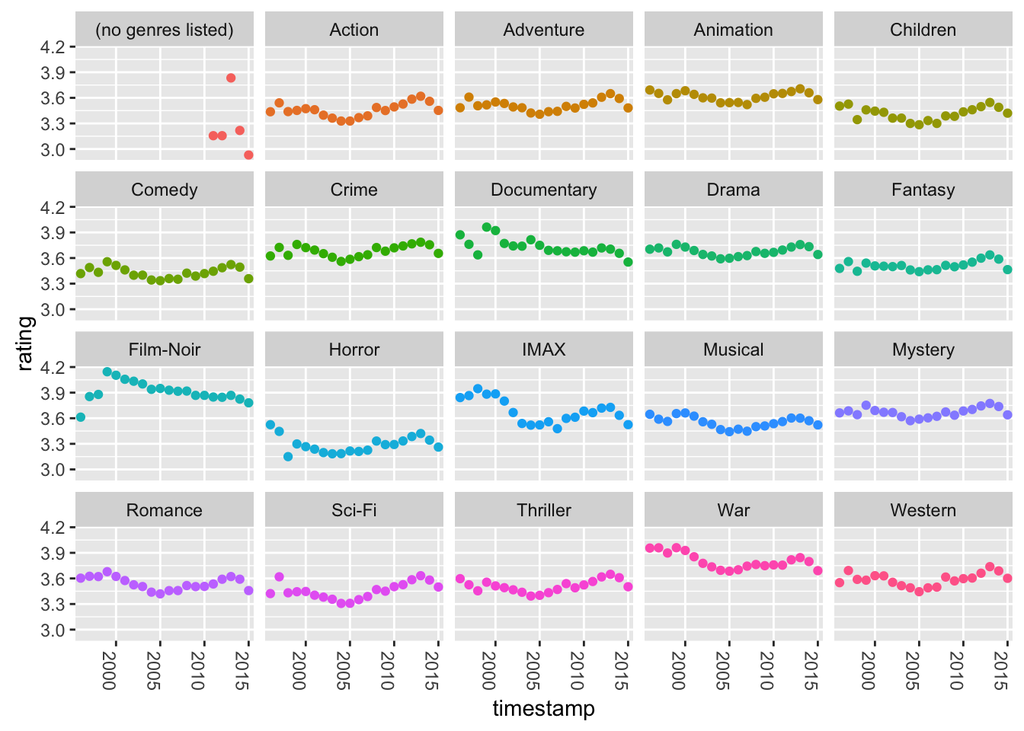

Analisando as maiores médias. Abaixo vemos os gêneros com maiores ratings

| genres | rating |
| --- | --- |
| Film-Noir | 3.911992 |
| War | 3.803397 |
| Documentary | 3.733566 |

## Questão 2

Para analisar os crescimentos e quedas na média, o data frame foi dividido em 2 períodos (análise visual de crescimento e queda). Mesmo acreditando que deve existir uma maneira melhor…

```r
cresc <- tout %>% filter(timestamp %in% c(2005:2013) & genres != "(no genres listed)")
queda <- tout %>% filter(timestamp %in% c(1999:2005) & genres != "(no genres listed)")
```

A partir dessa divisão pensei em duas maneiras para descobrir os gêneros com maiores quedas e os com maiores crescimentos. A primeira seria analisando o coeficiente angular da regressão linear.

Abaixo temos os gêneros que tiveram os maiores crescimentos na média.

```r
crescLm <- ddply(cresc %>% select(genres,timestamp,rating), "genres", function(x) coef(lm(rating ~ timestamp,data = x))[2])
names(crescLm)[2] <- "slope"
```

| genres | slope |
| --- | --- |
| Children | 0.04871 |
| Western | 0.04497 |
| Sci-Fi | 0.04297 |
| Action | 0.03989 |
| Romance | 0.03778 |
| IMAX | 0.03721 |

```r
quedaLm <- ddply(queda %>% select(genres,timestamp,rating), "genres", function(x) coef(lm(rating ~ timestamp,data = x))[2])
names(quedaLm)[2] <- "slope"
```

[output not shown]

E a segunda seria calcular a diferença entre o maior e o menor rating nesses períodos, por gênero. Para isso usei o pacote `sqldf`. Não gerou o mesmo resultado, a ordem não foi a mesma.

Crescimento na média.

```r
cresc <- sqldf("select genres, (max(rating) - min(rating)) diff from tagg where timestamp between 2005 and 2013 and genres != '(no genres listed)' group by genres order by diff desc")
```

| genres | diff |
| --- | --- |
| Sci-Fi | 0.3236 |
| Western | 0.2936 |
| Action | 0.2906 |
| Children | 0.261 |
| IMAX | 0.2497 |
| Thriller | 0.2463 |

Queda na média.

```r
decr <- sqldf("select genres, (max(rating) - min(rating)) diff from tagg where timestamp between 1999 and 2005 and genres != '(no genres listed)' group by genres order by diff desc")
```

| genres | diff |
| --- | --- |
| IMAX | 0.3661 |
| War | 0.2755 |
| Romance | 0.2598 |
| Documentary | 0.2232 |
| Comedy | 0.222 |
| Musical | 0.2194 |

## Questão 3

Para realizarmos o gráfico com a correlação entre os gêneros vamos primeiro verificar o número de vezes que um usuário forneceu determinado rate para um determinado gênero e a média, agrupando por `(user,genre)`.

```r
usrRatMax <- tout %>% filter(genres != "(no genres listed)") %>% group_by(userId,genres,rating) %>% summarise(count = n())
usrRatxCt <- usrRatMax %>% mutate(cxr = rating * count) %>% group_by(userId,genres) %>% summarise(avg = mean(cxr))
```

Agora, vamos padronizar a coluna de rating, por usuário (alguns usuários que veem mais filmes que outros).

```r
usrgensc <- ddply(usrRatxCt, "userId", function(x){ x$scavg = scale(x$avg)})
usrgensc <- mutate(usrgensc, genres = usrRatxCt$genres)
colnames(usrgensc) <- c("userId", "avgsc","genres")
```

Passamos agora os gênero para colunas para fazermos a correlação.

```r
usrgenres <- cast(usrgensc, userId ~ genres ,value= "avgsc")
```

Abaixo vemos o gráfico da correlação entre os gêneros.

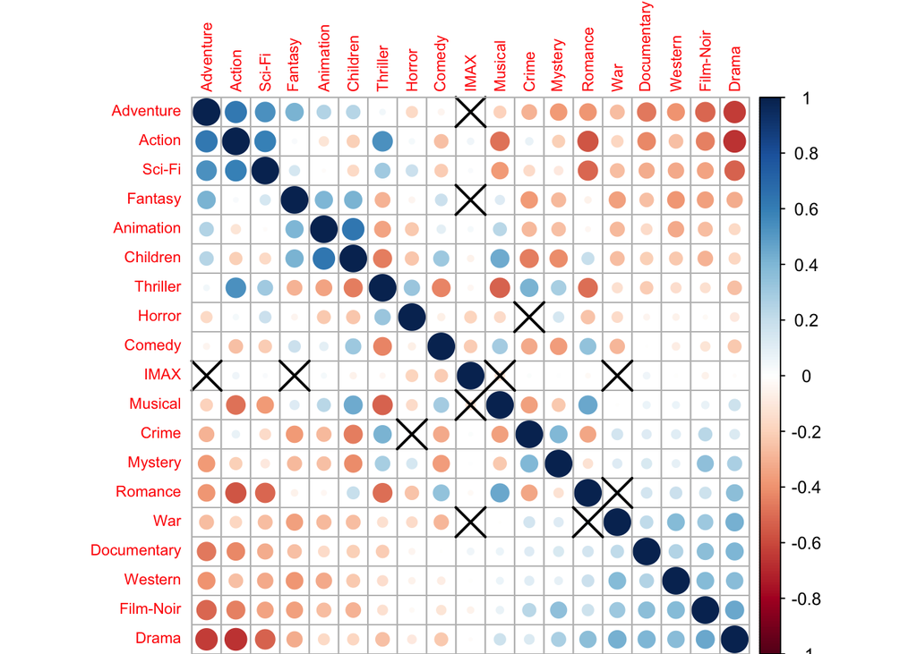

```r
genrcor <- cor(usrgenres[,2:20],use ="complete.obs")
dimnames(genrcor) <- list(colnames(usrgenres[2:20]),colnames(usrgenres[2:20]))
res1 <- cor.mtest(usrgenres[,2:20],0.95)
m <- genrcor
p <- cor.mtest(usrgenres[,2:20])
corrplot(m, p.mat = res1[[1]], order="FPC", insig = "pch",sig.level=0.001,tl.cex=0.7)
```

Vemos que, pessoas que gostam de gêneros como Aventura e/ou Ação e/ou Sci-Fi, não gostam de Dramas e/ou Filmes-Noir. E, quem gosta de Filmes-Noir e/ou Drama, não gosta de Aventura e Ação.

Em menor escala, quem gosta de Thriller gosta de Ação e não gosta de Musical ou Romance, quem gosta de Animação gosta de filmes de criança, quem gosta Musical também gosta de filmes de criança e Romance, mas não gosta de filmes de Ação ou Thriller.